# DEqMS Package

YAFENG ZHU @ Karolinska Institutet

2017-10-17

## Content

The Vignette is used to guide users to perform differential protein expression analysis:

1. Overview of DEqMS
2. Installation
3. Differential protein expression analysis
   - 3.1 Example Dataset: A431 cells treated with three different miRNA mimics
   - 3.2 Loading the data
   - 3.3 Generate a summary of the data
   - 3.4 Summarization and Normalization
   - 3.5 Ordinary T test
   - 3.6 Anova analysis
   - 3.7 Limma analysis
   - 3.8 Variance dependence on spectra count and non-linear regression
   - 3.9 DEqMS analysis
4. Comparing T test, Anova, Limma and DEqMS
5. Visualization of the results
   - 5.1 PSM/Peptide profile plot
   - 5.2 Volcano plot
   - 5.3 PCA plot
   - 5.4 Sample correlation heatmap
6. Conclusion
7. Session Information

## 1 Overview of DEqMS

`DEqMS` works on top of Limma, a widely-used R package for microarray data analysis (Smyth G. et al 2004), and improve it with mass spectrometry specific data properties, variance dependence on peptide spectra count for statistical testing of differential protein expression.

## 2 Installation

```r
source("DEqMS.R")
library(matrixStats)
library(plyr)
library(limma)
```

## 3 Differential protein expression analysis

### 3.1 Example Dataset: A431 cells treated with three different miRNA mimics

we analyzed a protemoics dataset (TMT10plex labelling) in which A431 cells (human epidermoid carcinoma cell line) were treated with three different miRNA mimics (Yan Z. et al. Oncogene 2016). The raw MS data was searched with MS-GF+ (Kim et al Nat Communications 2016) and post processed with Percolator (K??ll L. et al Nat Method 2007). A tabular text output of PSM intensity table filtered at 1% peptide level FDR is used as input for downstream analysis.

### 3.2 Loading the data and preprocess

Read a tabular input in which PSMs are in rows and samples are in columns. Intenisty values were log transformed since systematic effects and variance components are usually assumed to be additive on log scale (Oberg AL. et al JPR 2008; Hill EG. et al JPR 2008).

```r
dat.psm = read.table("miR_3-10_tmt10_psm_table.txt",stringsAsFactors = FALSE,sep="\t",header=T,comment.char = "",row.names = NULL)

dat.psm = na.omit(dat.psm)
dat.psm = dat.psm[!dat.psm$Protein.Group.Accessions=="",]
dat.psm[,3:12] =  log2(dat.psm[,3:12])

head(dat.psm)
```

```
##                  Sequence Protein.Group.Accessions     X126   X127_C
## 1              nDDDEEEAAR                 Q05682-5 14.34430 14.75081
## 2        dADADAGGGADGGDGR                   B0S8I7 16.07786 16.70725
## 3                 dEQSEEk                   P35579 14.82824 15.40075
## 4               eDAANNYAR   P68363;Q9BQE3;P68366-2 16.18069 16.41270
## 5 eDGNEEDkENQGDETQGQQPPQR                   P67809 13.84745 14.54231
## 6          eEEEEEEEDQEGDR                   Q15269 15.58373 15.81703
##     X127_N   X128_C   X128_N   X129_C   X129_N   X130_C   X130_N     X131
## 1 14.32404 14.89983 15.12161 15.00053 15.02626 15.31911 14.31132 15.40241
## 2 15.68852 15.99148 16.25322 16.52436 16.39507 16.75238 16.29957 16.94992
## 3 14.57400 15.10861 15.07138 15.33420 15.52894 15.59076 15.18107 15.76046
## 4 15.75577 16.39020 16.41369 16.34499 16.57267 16.66900 16.07556 17.14768
## 5 13.69479 14.18224 14.13731 14.30706 14.83071 14.17211 13.82873 14.93434
## 6 15.09218 15.30064 15.52925 15.68524 15.79867 15.55345 15.07932 16.18185
```

Generate sample annotation table.

```r
cond = c("ctrl","miR372","miR191","ctrl","miR519",
         "miR519","miR372","miR191","ctrl","miR372")

sampleTable <- data.frame(
  row.names = colnames(dat.psm)[3:12],
  cond = as.factor(cond)
)
sampleTable
```

```
##          cond
## X126     ctrl
## X127_C miR372
## X127_N miR191
## X128_C   ctrl
## X128_N miR519
## X129_C miR519
## X129_N miR372
## X130_C miR191
## X130_N   ctrl
## X131   miR372
```

### 3.3 Generate a summary of the data

Since each row is one PSM, to count how many PSMs per protein, we simply use function `table` in R to count the number of occurance that each protein ID appears.

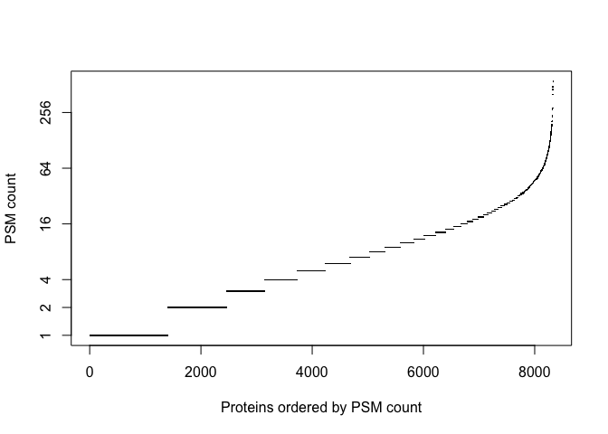

```r
psm.count.table = as.data.frame(table(dat.psm$Protein.Group.Accessions))
rownames(psm.count.table)=psm.count.table$Var1

plot(sort(log2(psm.count.table$Freq)),pch=".",yaxt="n",
     xlab="Proteins ordered by PSM count",ylab="PSM count")
ylab = lab<-c(1,2,4,16,64,256)
axis(2,at=log2(ylab),labels=ylab)
```

### 3.4 Summarization and Normalization

Here, median summarization and equal median normalization are used. In this procedure, we substract the spectrum log2 intensity from the mean log2 intensities of control samples. The relative abundance estimate for a particular protein is calculated as the median over all spectra belonging to this protein. Assume the log2 intensity of PSM `i` in sample `j` is $y_{i,j}$, its relative log2 intensity of PSM `i` in sample `j` is $y'_{i,j}$:
$$y'_{i,j} = y_{i,j} - mean_{j'\in ctrl}\ y_{i,j'}$$
Relative abundance of protein `k` in sample `j` $Y_{k,j}$ is calculated as:
$$Y_{k,j} = median_{i\in protein\ k}\ y'_{i,j}$$

Corrections for differences in amounts of material loaded in the channels and sample processing are done by subtracting the channel median from the relative abundance (log2 ratio), normalizing all channels to have median zero.

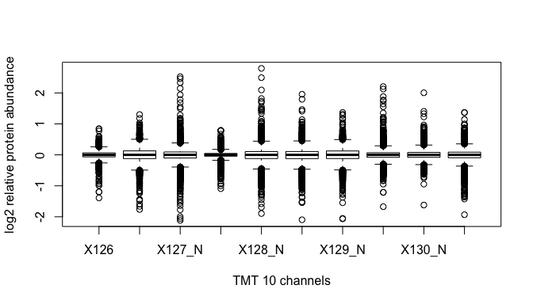

```r
dat.gene = median.summary(dat.psm,group_col = 2, ref_col=c(3,6,11))
dat.gene.nm = equal.median.normalization(dat.gene)
rownames(dat.gene.nm) = dat.gene[,1]

boxplot(dat.gene.nm,xlab="TMT 10 channels",ylab="log2 relative protein abundance")
```

### 3.5 Ordinary T test

We first apply t.test to detect significant protein changes between ctrl samples and miR372 treated samples, both have three replicates.

```r
pval.372 = apply(dat.gene.nm, 1, function(x)
  t.test(as.numeric(x[c(1,4,9)]), as.numeric(x[c(2,7,10)]))$p.value)

logFC.372 = rowMeans(dat.gene.nm[,c(2,7,10)])
```

Generate a data.frame of t.test results, add PSM count values and order the table by p-value.

```r
ttest.results = data.frame(gene=rownames(dat.gene.nm),
                           logFC=logFC.372,P.Value = pval.372,
                           adj.pval = p.adjust(pval.372,method = "BH"))

ttest.results$PSMcount = psm.count.table[ttest.results$gene,]$Freq
ttest.results = ttest.results[with(ttest.results, order(P.Value)), ]
write.table(ttest.results,"miR372_vs_ctrl.ttest.results.txt",quote=F,sep="\t",row.names = F)
head(ttest.results)
```

```
##              gene      logFC      P.Value   adj.pval PSMcount
## P30281-4 P30281-4 -0.2792297 3.222432e-06 0.02683964        1
## J3QS68     J3QS68  0.2773442 4.103077e-05 0.15197229        2
## P50452     P50452 -0.1628739 5.473849e-05 0.15197229       10
## P40189     P40189 -0.3927512 1.079804e-04 0.18032341        9
## J3QSE8     J3QSE8  0.1384881 1.082503e-04 0.18032341        5
## Q53EL6-2 Q53EL6-2 -0.8026815 1.531266e-04 0.19575383       12
```

### 3.6 Anova analysis

Anova analysis is equivalent to linear model analysis. The difference to Limma analysis is that estimated variance is not moderated using empirical bayesian approach as it is in Limma. The purpose here is to compare the statistical power to that when Limma is applied. We first make a design matrix and then use `lmFit` function in Limma for linear model analysis. The input for `lmFit` function is a matrix of relative protein abundance (log2 ratios) and a design matrix containing sample annotation. Use `head(fit$coefficients)` to see effect size(fold change) of genes for different conditions.

```r
gene.matrix = as.matrix(dat.gene.nm)
design = model.matrix(~cond,sampleTable)
design
```

```
##        (Intercept) condmiR191 condmiR372 condmiR519
## X126             1          0          0          0
## X127_C           1          0          1          0
## X127_N           1          1          0          0
## X128_C           1          0          0          0
## X128_N           1          0          0          1
## X129_C           1          0          0          1
## X129_N           1          0          1          0
## X130_C           1          1          0          0
## X130_N           1          0          0          0
## X131             1          0          1          0
## attr(,"assign")
## [1] 0 1 1 1
## attr(,"contrasts")
## attr(,"contrasts")$cond
## [1] "contr.treatment"
```

```r
fit1 <- lmFit(gene.matrix,design)

ord.t = fit1$coefficients[, 3]/fit1$sigma/fit1$stdev.unscaled[, 3]
ord.p = 2*pt(-abs(ord.t), fit1$df.residual)
ord.q = p.adjust(ord.p,method = "BH")
anova.results = data.frame(gene=names(fit1$sigma),
                           logFC=fit1$coefficients[,3],
                           t=ord.t,
                           P.Value=ord.p,
                           adj.P.Val = ord.q)

anova.results$PSMcount = psm.count.table[anova.results$gene,]$Freq
anova.results = anova.results[with(anova.results,order(P.Value)),]
write.table(anova.results,"miR372_vs_ctrl.anova.results.txt",quote=F,sep="\t",row.names = F)
head(anova.results)
```

```
##              gene      logFC         t      P.Value   adj.P.Val PSMcount
## O75116     O75116 -0.2017734 -19.58578 1.148054e-06 0.004576566       71
## Q13009-2 Q13009-2 -0.3158992 -17.69133 2.094537e-06 0.004576566        6
## Q53EL6-2 Q53EL6-2 -0.8168474 -16.72555 2.916229e-06 0.004576566       12
## Q8NB46     Q8NB46 -1.0651703 -16.59339 3.055705e-06 0.004576566        6
## C9J3D7     C9J3D7 -1.2076610 -16.58957 3.059845e-06 0.004576566        6
## Q96KB5     Q96KB5 -0.4059017 -16.38065 3.296842e-06 0.004576566       10
```

### 3.7 Limma analysis

Limma is essentially a combination of linear model analysis and empirical bayeisan estimation of variance, the latter is applied to increase the statistical power by borrowing informations across genes to shrink the variance.

```r
fit2 <- eBayes(lmFit(gene.matrix,design))
head(fit2$coefficients)
```

```
##           (Intercept)    condmiR191  condmiR372  condmiR519
## A0AVL1   -0.002803473 -0.0715810122 -0.17458240  0.14060060
## A0AVT1   -0.003036066  0.0754911122 -0.19837440 -0.20375372
## A0JLT2-2 -0.001944149 -0.0784026238  0.08347602  0.07235138
## A0JNW5    0.024226885  0.0005320687 -0.04952844 -0.05070177
## A0MZ66    0.003654952  0.0301469507  0.20088984  0.78626980
## A0PK00   -0.001944149  0.0310312942  0.19195142 -0.08566331
```

Extract limma results using `topTable` function, `coef = 3` allows you to extract the contrast of specific condition (miR372), option `n= Inf` output all rows instead of the top 10. Add PSM count values in the table.

```r
limma.results = topTable(fit2,coef = 3,n= Inf)
limma.results$gene = rownames(limma.results)
limma.results$PSMcount = psm.count.table[limma.results$gene,]$Freq
write.table(limma.results,"miR372_vs_ctrl.limma.results.txt",quote=F,sep="\t",row.names = F)
head(limma.results)
```

```
##               logFC    AveExpr         t      P.Value    adj.P.Val
## C9J3D7   -1.2076610 -0.3986992 -15.92089 2.492765e-08 0.0001805852
## Q8NB46   -1.0651703 -0.4954001 -15.01503 4.336299e-08 0.0001805852
## Q53EL6-2 -0.8168474 -0.2703124 -12.96342 1.718514e-07 0.0004771168
## P37173   -1.8856554 -0.9614027 -12.54906 2.324230e-07 0.0004839628
## Q9UHF7   -0.8356156 -0.3283049 -12.16902 3.090194e-07 0.0005147644
## F8W184    1.0629117  0.4557441  11.82983 4.011671e-07 0.0005277386
##                 B     gene PSMcount
## C9J3D7   9.178900   C9J3D7        6
## Q8NB46   8.755978   Q8NB46        6
## Q53EL6-2 7.645033 Q53EL6-2       12
## P37173   7.391018   P37173        1
## Q9UHF7   7.148187   Q9UHF7       12
## F8W184   6.923083   F8W184        1
```

### 3.8 Variance dependence on spectra count

We observed that the variance of gene across samples gradually decreases as the number of spectra count increases.

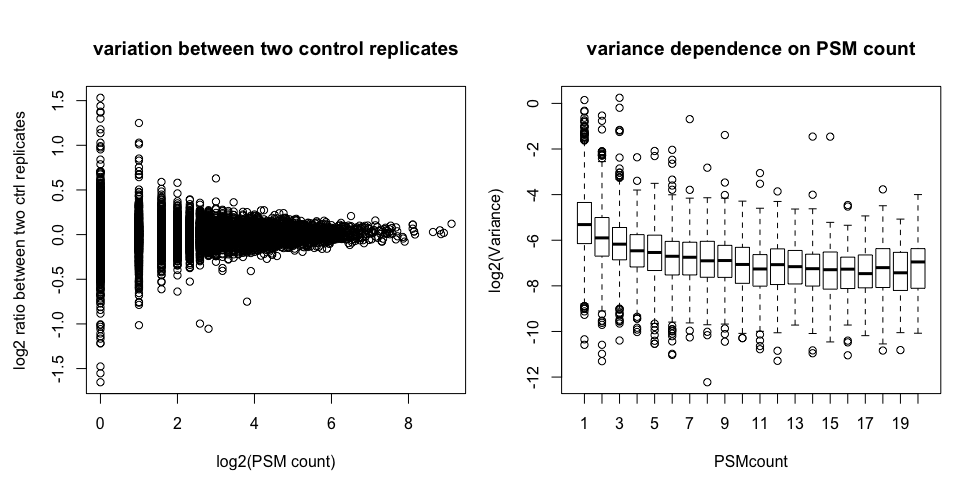

```r
dat.temp = data.frame(var = fit2$sigma^2,PSMcount = psm.count.table[names(fit2$sigma),]$Freq)
dat.temp.filter = dat.temp[dat.temp$PSMcount<21,]

op <- par(mfrow=c(1,2), mar=c(4,4,4,1), oma=c(0.5,0.5,0.5,0))
plot(log2(psm.count.table[rownames(dat.gene.nm),2]),dat.gene.nm[,1]-dat.gene.nm[,4],xlab="log2(PSM count)",ylab="log2 ratio between two ctrl replicates",main="variation between two control replicates")

boxplot(log2(var)~PSMcount,dat.temp.filter,xlab="PSMcount",ylab="log2(Variance)",main="variance dependence on PSM count")
```

### 3.9 DEqMS analysis

Limma assumes same prior variance for all genes, the function `spectra.count.eBayes` in DEqMS package is able to correct the biase of prior variance estimate for genes identified with different number of PSMs. It works in a similar way to the intensity-based hierarchical Bayes method (Maureen A. Sartor et al BMC Bioinformatics 2006). Intead of locally weighted regression (Maureen et al 2006) between prior variance and intensity, DEqMS use `nls` function with an explicit fomula (Var ~ const+A/(spectra.count)) to fit prior variance against PSM count.  
Outputs of `spectra.count.eBayes`:  
object is augmented form of “fit” object from `eBayes` in Limma, with the additions being:  
`sca.t` - Spectra Count Adjusted posterior t-value  
`sca.p` - Spectra Count Adjusted posterior p-value  
`sca.dfprior` - estimated prior degrees of freedom  
`sca.priorvar`- estimated prior variance  
`sca.postvar` - estimated posterior variance  
`nls.model` - fitted non-linear model

```r
fit2$PSM.count = psm.count.table[names(fit2$sigma),]$Freq

fit3 = spectra.count.eBayes(fit2,3)
```

```
## [1] "non linear regression (Var ~ const+A/(spectra.count))"
## [1] "Prior degrees freedom found"
## [1] "P-values calculated"
```

```r
sca.results = topTable(fit3,coef = 3,n= Inf)

sca.results$gene = row.names(sca.results)
sca.results$PSM.count = psm.count.table[rownames(sca.results),]$Freq
sca.results$sca.t = fit3$sca.t[rownames(sca.results)]
sca.results$sca.P.Value = fit3$sca.p[rownames(sca.results)]
sca.results$sca.adj.pval = p.adjust(sca.results$sca.P.Value,method = "BH")

sca.results = sca.results[with(sca.results, order(sca.P.Value)), ]
head(sca.results)
```

```
##               logFC    AveExpr         t      P.Value    adj.P.Val
## C9J3D7   -1.2076610 -0.3986992 -15.92089 2.492765e-08 0.0001805852
## Q8NB46   -1.0651703 -0.4954001 -15.01503 4.336299e-08 0.0001805852
## Q53EL6-2 -0.8168474 -0.2703124 -12.96342 1.718514e-07 0.0004771168
## Q9UHF7   -0.8356156 -0.3283049 -12.16902 3.090194e-07 0.0005147644
## Q9BQS8   -0.6570793 -0.1982400 -10.71849 9.902524e-07 0.0008803855
## P37173   -1.8856554 -0.9614027 -12.54906 2.324230e-07 0.0004839628
##                 B     gene PSM.count     sca.t  sca.P.Value sca.adj.pval
## C9J3D7   9.178900   C9J3D7         6 -14.80561 2.528583e-08 0.0002106056
## Q8NB46   8.755978   Q8NB46         6 -13.78196 5.152619e-08 0.0002145808
## Q53EL6-2 7.645033 Q53EL6-2        12 -12.80856 1.061488e-07 0.0002947046
## Q9UHF7   7.148187   Q9UHF7        12 -12.09999 1.853854e-07 0.0003860188
## Q9BQS8   6.125520   Q9BQS8        24 -11.24511 3.779016e-07 0.0006295084
## P37173   7.391018   P37173         1 -10.61348 6.594966e-07 0.0008859152
```

```r
write.table(sca.results,"miR372_vs_ctrl.DEqMS.results.txt",quote=F,sep="\t",row.names = F)
```

Check if the fitted non-linear model is correct.

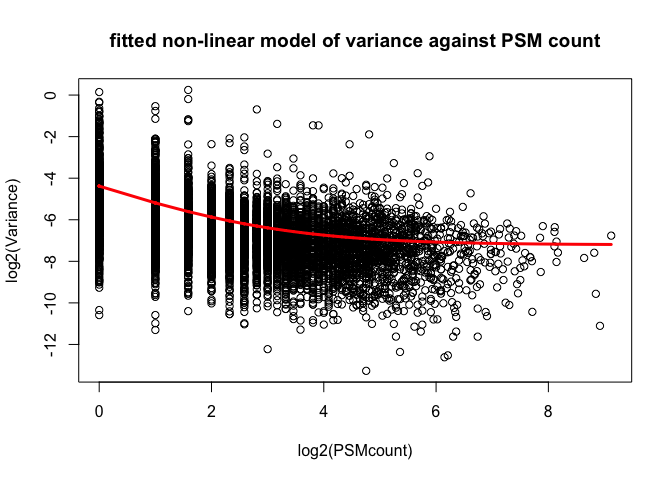

```r
plot.nls.fit(fit3)
```

## 4 Comparing T test, Anova, Limma and DEqMS

### 4.1 the effect of spectra.count.eBayes function on variance and p-values

Visualize the change of posterior variance after PSM count adjustment. The plot here shows posterior variance of proteins “shrink” toward the fitted value to different extent depending on PSM number.

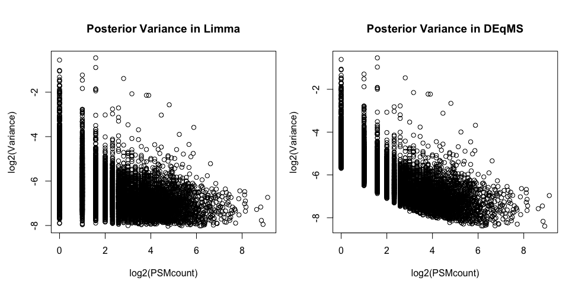

```r
x = fit3$PSM.count
y = fit3$s2.post
op <- par(mfrow=c(1,2), mar=c(4,4,4,1), oma=c(0.5,0.5,0.5,0))
plot(log2(x),log2(y),xlab = "log2(PSMcount)",ylab="log2(Variance)",main="Posterior Variance in Limma")

y = fit3$sca.postvar
plot(log2(x),log2(y),xlab = "log2(PSMcount)",ylab="log2(Variance)",main="Posterior Variance in DEqMS")
```

Here we want to see how p-values changed after applying `spectra.count.eBayes` in DEqMS. As shown in this figure, p-values (ctrl vs miR372) of proteins identified with low number of PSMs become larger (less significant) compared to p-values reported from limma, while p-values of proteins with high PSM number are mostly unaffected.

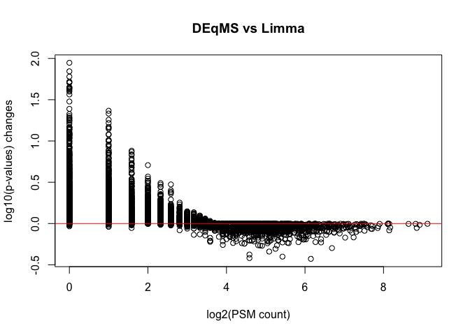

```r
plot(log2(sca.results$PSM.count),log10(sca.results$sca.P.Value)-log10(sca.results$P.Value),xlab="log2(PSM count)",ylab="log10(p-values) changes",main="DEqMS vs Limma")
abline(h=0,col="red")
```

### 4.2 Comparing p-values by different analysis.

plotting top 500 genes ranked by p-values.

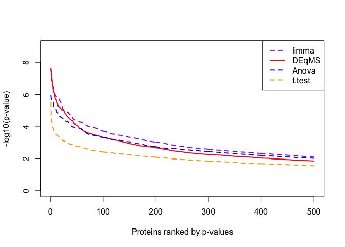

```r
plot(sort(-log10(limma.results$P.Value),decreasing = T)[1:500], type="l",lty=2,lwd=2, ylab="-log10(p-value)",xlab="Proteins ranked by p-values",col="purple",ylim=c(0,9))
lines(sort(-log10(sca.results$sca.P.Value),decreasing = T)[1:500], lty=1,lwd=2,col="red")
lines(sort(-log10(anova.results$P.Value),decreasing = T)[1:500], lty=2,lwd=2,col="blue")
lines(sort(-log10(ttest.results$P.Value),decreasing = T)[1:500], lty=2,lwd=2,col="orange")
legend("topright",legend = c("limma","DEqMS","Anova","t.test"),col = c("purple","red","blue","orange"),lty=c(2,1,2,2),lwd=2)
```

### 4.3 Make a null comparison

The purpose is to see how many false positives we get from different tests. Group 1 (ctrl+miR372+miR191) and Group 2 (ctrl+miR372+miR191) were compared here, we should not expect significant hits from the statistical tests.

```r
shuffle.cond = c("1","1","1","3","3",
         "4","4","2","2","2")

shuffle.Table <- data.frame(
  row.names = colnames(dat.psm)[3:12],
  false.cond = as.factor(shuffle.cond),
  true.cond = as.factor(cond)
)

shuffle.Table
```

```
##        false.cond true.cond
## X126            1      ctrl
## X127_C          1    miR372
## X127_N          1    miR191
## X128_C          3      ctrl
## X128_N          3    miR519
## X129_C          4    miR519
## X129_N          4    miR372
## X130_C          2    miR191
## X130_N          2      ctrl
## X131            2    miR372
```

```r
shuffle.design = model.matrix(~false.cond,shuffle.Table)
```

Do t.test on falsely labelled conditions.

```r
null.ttest.pval = apply(dat.gene.nm, 1, function(x)
  t.test(as.numeric(x[c(1,2,3)]), as.numeric(x[c(8,9,10)]))$p.value)
```

Anova, limma and DEqMS analysis on the Null Comparison.

```r
null.fit1 = lmFit(gene.matrix,shuffle.design)
null.fit1$t.value = null.fit1$coefficients[, 2]/null.fit1$sigma/null.fit1$stdev.unscaled[, 2]
null.fit1$p.value = 2*pt(-abs(null.fit1$t.value), null.fit1$df.residual)


null.fit2 = eBayes(null.fit1)
null.fit2$PSM.count = psm.count.table[names(null.fit2$sigma),]$Freq

null.fit3 = spectra.count.eBayes(null.fit2,2)
```

```
## [1] "non linear regression (Var ~ const+A/(spectra.count))"
## [1] "Prior degrees freedom found"
## [1] "P-values calculated"
```

```r
head(null.fit2$coefficients)
```

```
##           (Intercept) false.cond2  false.cond3 false.cond4
## A0AVL1   -0.107175664  0.03428625  0.166388770  0.11118881
## A0AVT1   -0.008761033 -0.06342329 -0.084714268 -0.21735017
## A0JLT2-2 -0.072866430  0.22609900  0.154021034 -0.01939533
## A0JNW5    0.019034738 -0.03416655 -0.007499025 -0.03975277
## A0MZ66    0.079332681 -0.03255456  0.342716763  0.44547794
## A0PK00    0.136580851  0.02391703 -0.389735726 -0.10546970
```

Plotting top 100 genes ranked by p-values.

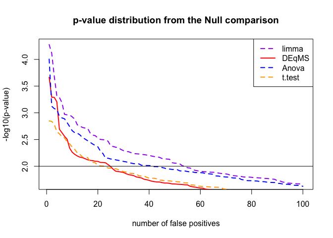

```r
plot(sort(-log10(null.fit2$p.value[,2]),decreasing = T)[1:100], type="l",lty=2,lwd=2, ylab="-log10(p-value)",xlab="number of false positives",col="purple",
     main = "p-value distribution from the Null comparison")
lines(sort(-log10(null.fit3$sca.p),decreasing = T)[1:100], lty=1,lwd=2,col="red")
lines(sort(-log10(null.fit1$p.value),decreasing = T)[1:100], lty=2,lwd=2,col="blue")
lines(sort(-log10(null.ttest.pval),decreasing = T)[1:100], lty=2,lwd=2,col="orange")
legend("topright",legend = c("limma","DEqMS","Anova","t.test"),col = c("purple","red","blue","orange"),lty=c(2,1,2,2),lwd=2)
abline(h=2)
```

### 5 Visualization of the results